# Implementing Machine Learning

10/1/2018

## General Types of Supervised Learning

– Regression (predict a continuous variable) with "wine quality" dataset

– Classification (predict category membership) with "breast cancer" dataset

– Classification (predict category membership) with "wine quality" dataset: Good and bad wine

## Kaggle Data Repository (https://www.kaggle.com)

– Kaggle hosts machine learning competitions, data, and advice

– Wisconsin Cancer Diagnosis Data https://www.kaggle.com/uciml/breast-cancer-wisconsin-data

– Wine Quality Data https://www.kaggle.com/uciml/red-wine-quality-cortez-et-al-2009

## caret Package for Machine Learning

http://topepo.github.io/caret/index.html

– Provides an integrated set of functions to support machine learning

– Provides uniform interface to over 200 algorithms (e.g., linear regression, random forest, support vector machines)

– Makes training and testing many types of models very easy

– Incorporates sensible defaults that often work well

## Simplified Machine Learning Process

– Partition data into training and test sets

– Pre-process data and select features

– Tune model hyperparameters with cross validation

– Estimate variable importance

– Assess predictions and model performance with test data

– Compare model performance

## Read and Visualize Data

```r
wine.df = read_csv("winequality-red.csv")
skim(wine.df)
```

```
## Skim summary statistics
##  n obs: 1599
##  n variables: 12
##
## ── Variable type:integer ─────────────────────────────────────────────────────────────────────────────────────────────────────────────────
##  variable missing complete    n mean   sd p0 p25 p50 p75 p100     hist
##   quality       0     1599 1599 5.64 0.81  3   5   6   6    8 ▁▁▁▇▇▁▂▁
##
## ── Variable type:numeric ─────────────────────────────────────────────────────────────────────────────────────────────────────────────────
##              variable missing complete    n   mean      sd    p0   p25
##               alcohol       0     1599 1599 10.42   1.07   8.4    9.5
##             chlorides       0     1599 1599  0.087  0.047  0.012  0.07
##           citric acid       0     1599 1599  0.27   0.19   0      0.09
##               density       0     1599 1599  1      0.0019 0.99   1
##         fixed acidity       0     1599 1599  8.32   1.74   4.6    7.1
##   free sulfur dioxide       0     1599 1599 15.87  10.46   1      7
##                    pH       0     1599 1599  3.31   0.15   2.74   3.21
##        residual sugar       0     1599 1599  2.54   1.41   0.9    1.9
##             sulphates       0     1599 1599  0.66   0.17   0.33   0.55
##  total sulfur dioxide       0     1599 1599 46.47  32.9    6     22
##      volatile acidity       0     1599 1599  0.53   0.18   0.12   0.39
##     p50   p75   p100     hist
##  10.2   11.1   14.9  ▂▇▅▃▂▁▁▁
##   0.079  0.09   0.61 ▇▃▁▁▁▁▁▁
##   0.26   0.42   1    ▇▅▅▆▂▁▁▁
##   1      1      1    ▁▁▃▇▇▂▁▁
##   7.9    9.2   15.9  ▁▇▇▅▂▁▁▁
##  14     21     72    ▇▇▅▂▁▁▁▁
##   3.31   3.4    4.01 ▁▁▅▇▅▁▁▁
##   2.2    2.6   15.5  ▇▂▁▁▁▁▁▁
##   0.62   0.73   2    ▂▇▂▁▁▁▁▁
##  38     62    289    ▇▅▂▁▁▁▁▁
##   0.52   0.64   1.58 ▂▇▇▃▁▁▁▁
```

## Read and Visualize Data

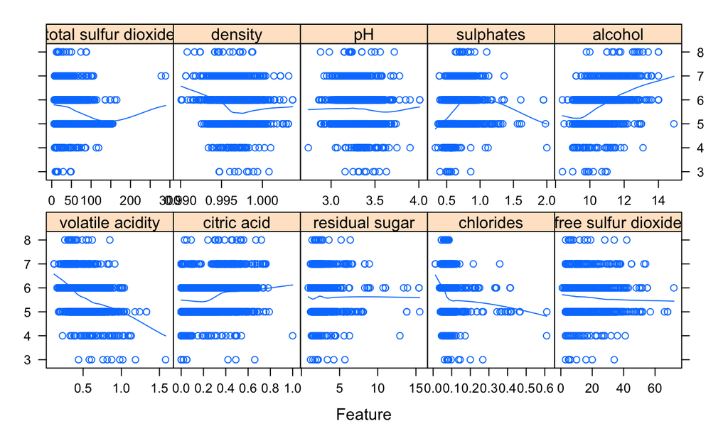

```r
featurePlot(x = wine.df[, 2:11], y = wine.df$quality,
            plot = "scatter",
            type = c("p", "smooth"), span = .5,
            layout = c(5, 2))
```

## Define Class Variable

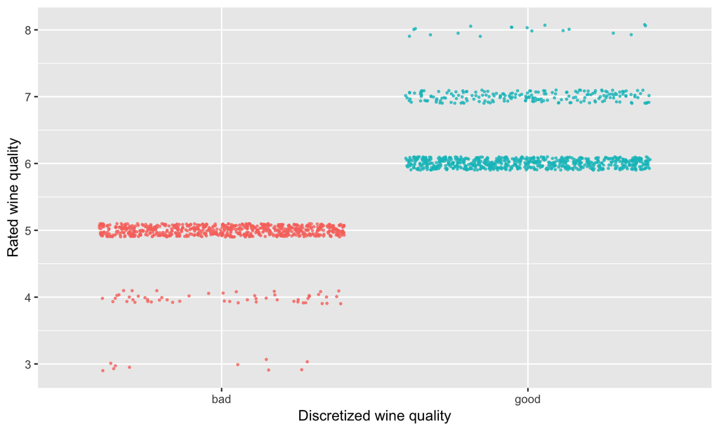

```r
quality.wine.df = wine.df %>% mutate(goodwine = if_else(quality>5, "good", "bad")) %>%
  mutate(goodwine = as.factor(goodwine))

ggplot(quality.wine.df, aes(goodwine, quality, colour = goodwine, fill = goodwine))+
  geom_point(size = .5, alpha = .7, position = position_jitter(height = 0.1))+
  labs(x = "Discretized wine quality", y = "Rated wine quality")+
  theme(legend.position = "none")
```

```r
wine.df = quality.wine.df %>% select(-quality)
```

## Partition Data into Training and Testing

– Proportions of class variable—good and bad wine—should be similar

– Proportions of class variables should be similar in test and training data

– `createDataPartition` Creates partitions that maintains the class distribution

## Partition Data into Training and Testing

```r
inTrain = createDataPartition(wine.df$goodwine, p = 3/4, list = FALSE)

trainDescr = wine.df[inTrain, -12] # All but class variable
testDescr = wine.df[-inTrain, -12]

trainClass = wine.df$goodwine[inTrain]
testClass = wine.df$goodwine[-inTrain]
```

## Partition Data into Training and Testing

```r
wine.df$goodwine %>%  table() %>% prop.table() %>% round(3)*100
```

```
## .
##  bad good
## 46.5 53.5
```

```r
trainClass %>% table() %>% prop.table() %>% round(3)*100
```

```
## .
##  bad good
## 46.5 53.5
```

```r
testClass %>% table() %>% prop.table() %>% round(3)*100
```

```
## .
##  bad good
## 46.6 53.4
```

## Pre-process Data: Filter poor predictors

– Eliminate variables with no variabilty

– Eliminate highly correlated variables

– Select predictive features

– Engineer predictive features

## Pre-process Data: Normalization

– `preProcess` also supports other preprocessing methods, such as PCA and ICA

– `center` subtracts mean

– `scale` normalizes based on standard deviation

```r
xTrans = preProcess(trainDescr, method = c("center", "scale"))
trainScaled = predict(xTrans, trainDescr)
testScaled = predict(xTrans, testDescr)
```

## Pre-process Data: Normalization

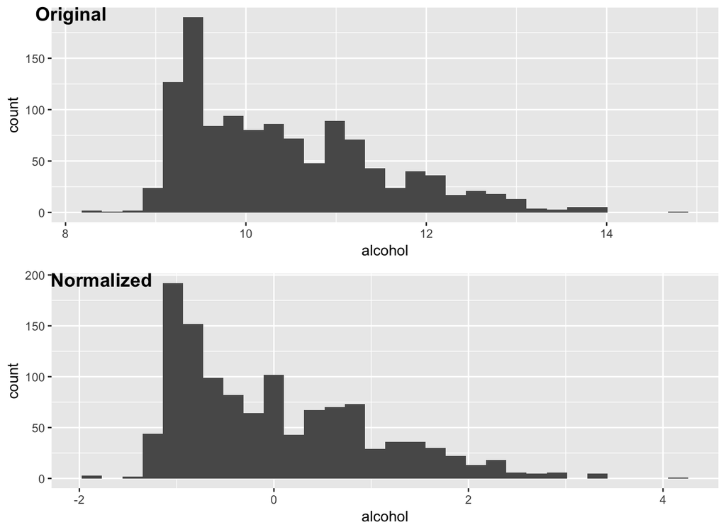

## Exercise: Partition and pre-process data

– Load and review the Wisconsin cancer data

`cancer.df = read_csv("cancer.csv")`

`skim(cancer.df)`

– Identify the diagnosis indicator

– Partition data

`inTrain = createDataPartition(cancer.df$diagnosis, p = 3/4, list = FALSE)`

`trainDescr = cancer.df[inTrain, -(1:2)] # All but class variable`

`testDescr = cancer.df[-inTrain, -(1:2)]`

`trainClass = cancer.df$diagnosis[inTrain]`

`testClass = cancer.df$diagnosis[-inTrain]`

– Pre-process data

`xTrans = preProcess(trainDescr, method = c("center", "scale"))`

`trainScaled = predict(xTrans, trainDescr)`

`testScaled = predict(xTrans, testDescr)`

## Cross Validation

– Used to select best combination of predictors and model parameters

– Estimates model performance (e.g., AUC or r-square) for each candidate model

– Uses a random subset of the training data to train the model and a withheld subset to test

## Grouped Cross-validation

### Sleep study example

`sleep.df = sleepstudy`  
`folds <- groupKFold(sleep.df$Subject, k = 18)`

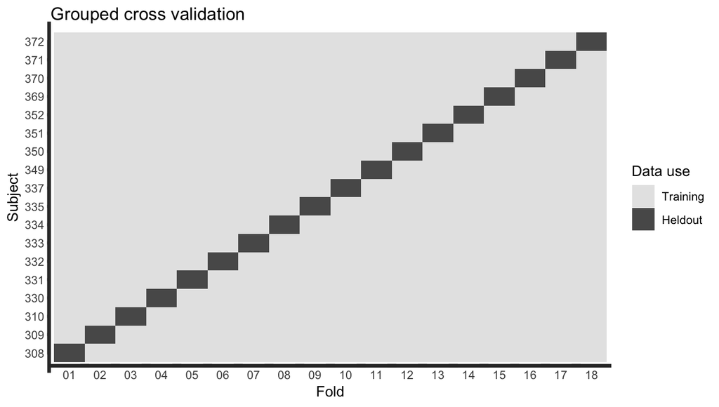

## Define Training Parameters

– Select cross validation method: 10-fold repeated cross validation is common

– Define hyperparameter selection method: grid search is the simplest approach

– Define summary measures

– `trainControl` command specifies all these parameters in a single statement

## Define Training Parameters: `trainControl`

```r
train.control = trainControl(method = "repeatedcv",
                              number = 10, repeats = 3, # number: number of folds
                              search = "grid", # for tuning hyperparameters
                              classProbs = TRUE,
                              savePredictions = "final",
                              summaryFunction = twoClassSummary)
```

## Select Models to Train

– Over 200 different models from 50 categories (e.g., Linear regression, boosting, bagging, cost sensitive learning)

– List of models: http://caret.r-forge.r-project.org/modelList.html

– The "train" statement can train any of them

– Here we select three:

```
- Logistic regression

- Support vector machine

- Xgboost, a boosted random forest that performs well in many situations
```

## Train Models and Tune Hyperparameters with the `train` function

– Specify class and predictor variables

– Specify one of the over 200 models (e.g., xgboost)

– Specify the metric, such as ROC

– Include the train control specified earlier

## Train Models and Tune Hyperparameters: Logistic regression

– Logistic regression has no tuning parameters

– 10-fold repeated (3 times) cross-validation occurs once

– Produces a total of 30 instances of model fitting and testing

– Cross validation provides a nearly unbiased estimate of the performance of the model on the held out data

## Train Models and Tune Hyperparameters: Logistic regression

```r
glm.fit = train(x = trainScaled, y = trainClass,
   method = 'glm', metric = "ROC",
   trControl = train.control)

glm.fit
```

```
## Generalized Linear Model
##
## 1200 samples
##   11 predictor
##    2 classes: 'bad', 'good'
##
## No pre-processing
## Resampling: Cross-Validated (10 fold, repeated 3 times)
## Summary of sample sizes: 1080, 1080, 1080, 1080, 1080, 1079, ...
## Resampling results:
##
##   ROC        Sens       Spec
##   0.8101622  0.7233874  0.7523798
```

## Train Models and Tune Hyperparameters: Support vector machine

- Linear support vector machines have a single tuning parameter–C
- C (Cost)
- C = 1000 "hard margin" tends to be sensitive to individual data points and is prone to over fitting

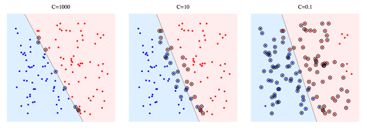

https://stackoverflow.com/questions/4629505/svm-hard-or-soft-margins

## Train Models and Tune Hyperparameters: Support vector machine

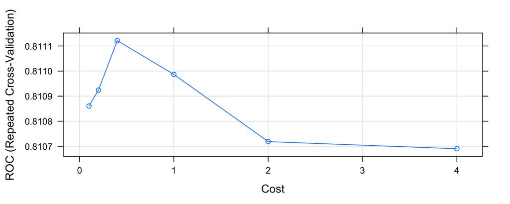

```r
grid = expand.grid(C = c(.1, .2, .4, 1, 2, 4))
svm.fit =  train(x = trainScaled, y = trainClass,
  method = "svmLinear", metric = "ROC",
  tuneGrid = grid, # Overrides tuneLength
  tuneLength = 3, # Number of levels of each hyper parameter, unless specified by grid
  trControl = train.control, scaled = TRUE)

plot(svm.fit)
```

## Train Models and Tune Hyperparameters: xgboost

Classification depends on adding outcomes across many trees

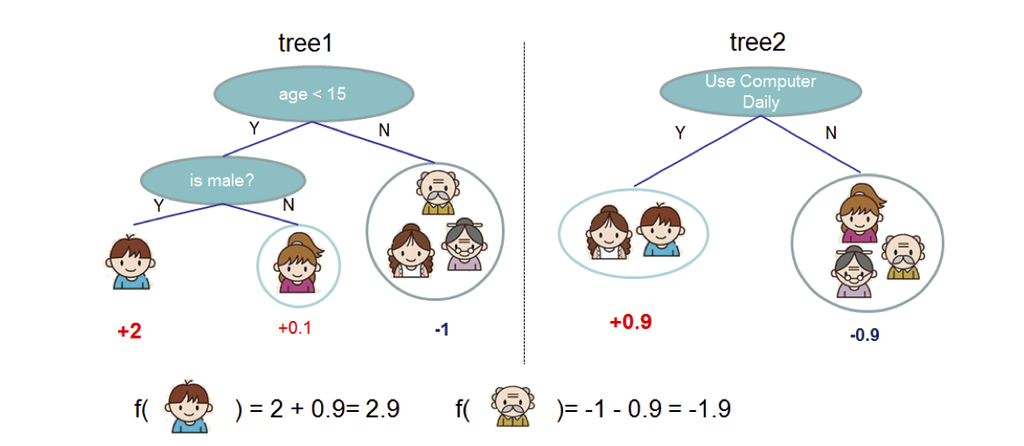

Chen, T., & Guestrin, C. (2016). XGBoost: A scalable tree boosting system. Proceedings of the 22nd ACM SIGKDD International Conference on Knowledge Discovery and Data Mining, 785–794.

## Train Models and Tune Hyperparameters: xgboost

Trees are built in sequence to address the errors (residuals) of the previous trees

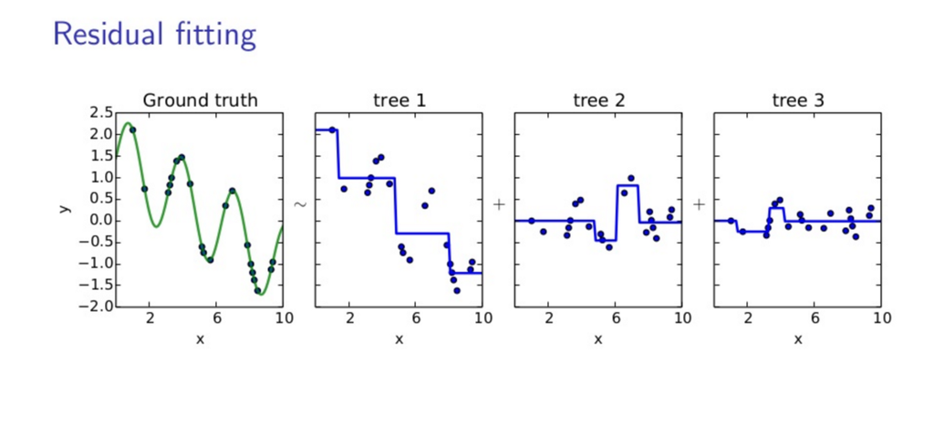

https://towardsdatascience.com/

## Train Models and Tune Hyperparameters: xgboost

– nrounds (# Boosting Iterations)–model robustness

– max_depth (Max Tree Depth)–model complexity

– eta (Shrinkage)–model robustness

– gamma (Minimum Loss Reduction)–model complexity

– colsample_bytree (Subsample Ratio of Columns)–model robustness

– min_child_weight (Minimum Sum of Instance Weight)–model complexity

– subsample (Subsample Percentage)–model robustness

**A grid search with 3 levels for each parameter produces 3^7 combinations!**

## Train Models and Tune Hyperparameters: xgboost

`tuneLength = 3` produces

```
- nrounds (# Boosting Iterations) (50 100 150)

- max_depth (Max Tree Depth) (1, 2, 3)

- eta (Shrinkage) (.3, .4)

- gamma (Minimum Loss Reduction) (0)

- colsample_bytree (Subsample Ratio of Columns) (.6, .8)

- min_child_weight (Minimum Sum of Instance Weight) (1)

- subsample (Subsample Percentage) (.50, .75, 1.0)
```

– 108 different model combinations each trained and tested 10X3 times

## Train models and tune Hyperparameters: xgboost

```r
xgb.fit = train(x = trainScaled, y = trainClass,
  method = "xgbTree", metric = "ROC",
  tuneLength = 3, # Depends on number of parameters in algorithm
  trControl = train.control, scaled = TRUE)
```

## Train models and tune: xgboost

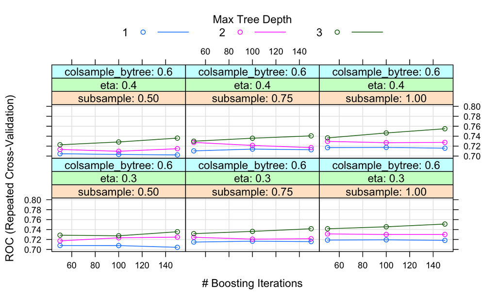

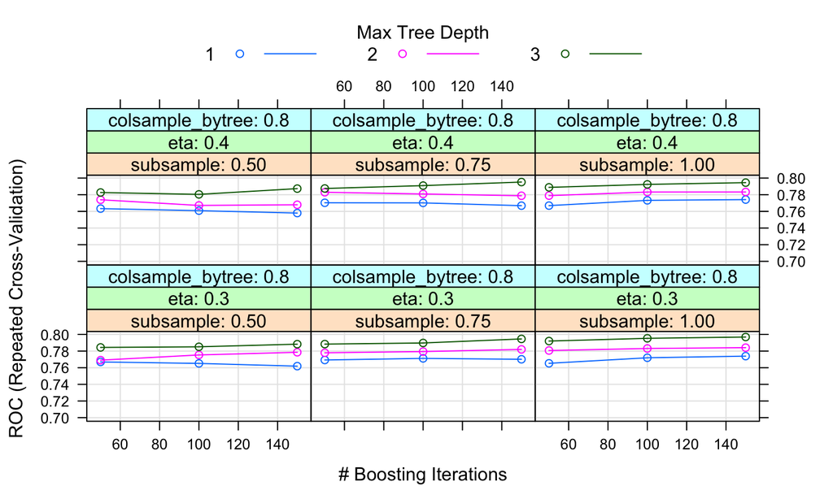

## Exercise: Train and Tune Hyperparameters

– Set training parameters

`train.control =`  
`trainControl(method = "repeatedcv",`  
`number = 10, repeats = 3, # number: number of folds`  
`search = "grid", # for tuning hyperparameters`  
`classProbs = TRUE,`  
`savePredictions = "final",`  
`summaryFunction = twoClassSummary)`

– Train an extreme boosting tree

`xgb.fit = train(x = trainScaled, y = trainClass,`  
`method = "xgbTree", metric = "ROC",`  
`tuneLength = 3, # Depends on number of parameters in algorithm`  
`trControl = train.control, scaled = TRUE)`

– Identify the best combination of Hyperparameters

## Assess Performance: Confusion matrix (glm)

```r
glm.pred = predict(glm.fit, testScaled)

confusionMatrix(glm.pred, testClass)
```

```
## Confusion Matrix and Statistics
##
##           Reference
## Prediction bad good
##       bad  124   48
##       good  62  165
##
##                Accuracy : 0.7243
##                  95% CI : (0.6777, 0.7676)
##     No Information Rate : 0.5338
##     P-Value [Acc > NIR] : 4.895e-15
##
##                   Kappa : 0.4434
##  Mcnemar's Test P-Value : 0.2152
##
##             Sensitivity : 0.6667
##             Specificity : 0.7746
##          Pos Pred Value : 0.7209
##          Neg Pred Value : 0.7269
##              Prevalence : 0.4662
##          Detection Rate : 0.3108
##    Detection Prevalence : 0.4311
##       Balanced Accuracy : 0.7207
##
##        'Positive' Class : bad
##
```

## Assess Performance: Confusion matrix (svm)

```r
svm.pred = predict(svm.fit, testScaled)

confusionMatrix(svm.pred, testClass)
```

```
## Confusion Matrix and Statistics
##
##           Reference
## Prediction bad good
##       bad  128   49
##       good  58  164
##
##                Accuracy : 0.7318
##                  95% CI : (0.6855, 0.7747)
##     No Information Rate : 0.5338
##     P-Value [Acc > NIR] : 3.758e-16
##
##                   Kappa : 0.4595
##  Mcnemar's Test P-Value : 0.4393
##
##             Sensitivity : 0.6882
##             Specificity : 0.7700
##          Pos Pred Value : 0.7232
##          Neg Pred Value : 0.7387
##              Prevalence : 0.4662
##          Detection Rate : 0.3208
##    Detection Prevalence : 0.4436
##       Balanced Accuracy : 0.7291
##
##        'Positive' Class : bad
##
```

## Assess Performance: Confusion matrix (xgb)

```r
xgb.pred = predict(xgb.fit, testScaled)

confusionMatrix(xgb.pred, testClass)
```

```
## Confusion Matrix and Statistics
##
##           Reference
## Prediction bad good
##       bad  157   19
##       good  29  194
##
##                Accuracy : 0.8797
##                  95% CI : (0.8437, 0.91)
##     No Information Rate : 0.5338
##     P-Value [Acc > NIR] : <2e-16
##
##                   Kappa : 0.7575
##  Mcnemar's Test P-Value : 0.1939
##
##             Sensitivity : 0.8441
##             Specificity : 0.9108
##          Pos Pred Value : 0.8920
##          Neg Pred Value : 0.8700
##              Prevalence : 0.4662
##          Detection Rate : 0.3935
##    Detection Prevalence : 0.4411
##       Balanced Accuracy : 0.8774
##
##        'Positive' Class : bad
##
```

## Compare Models

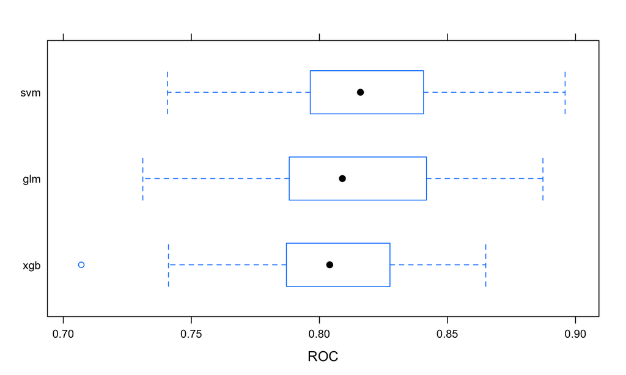

```r
mod.resamps = resamples(list(glm = glm.fit, svm = svm.fit, xgb = xgb.fit))

bwplot(mod.resamps, metric="ROC")
```

```r
# dotplot(mod.resamps, metric="ROC")
```

## Assess Performance (xgb): ROC plot

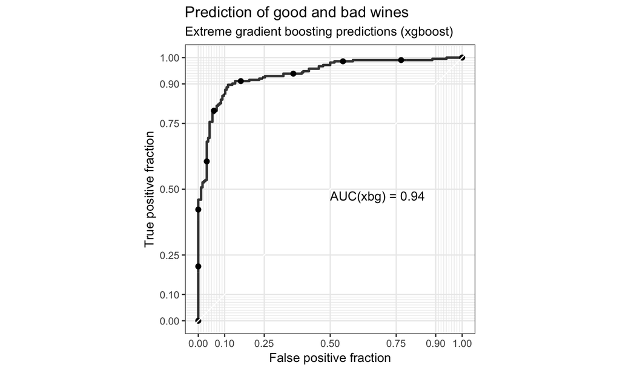

## xgboost Predictions

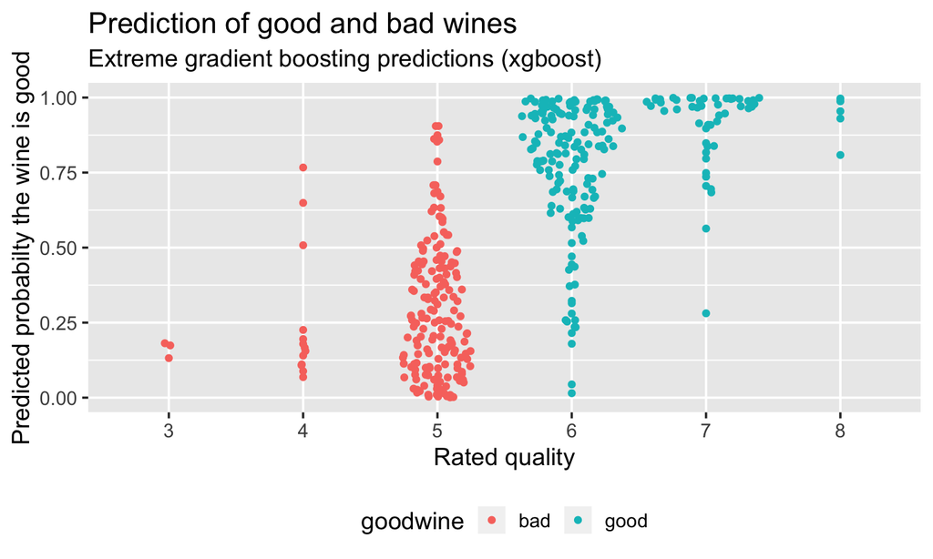

## Assess Variable Importance: glm and xgb

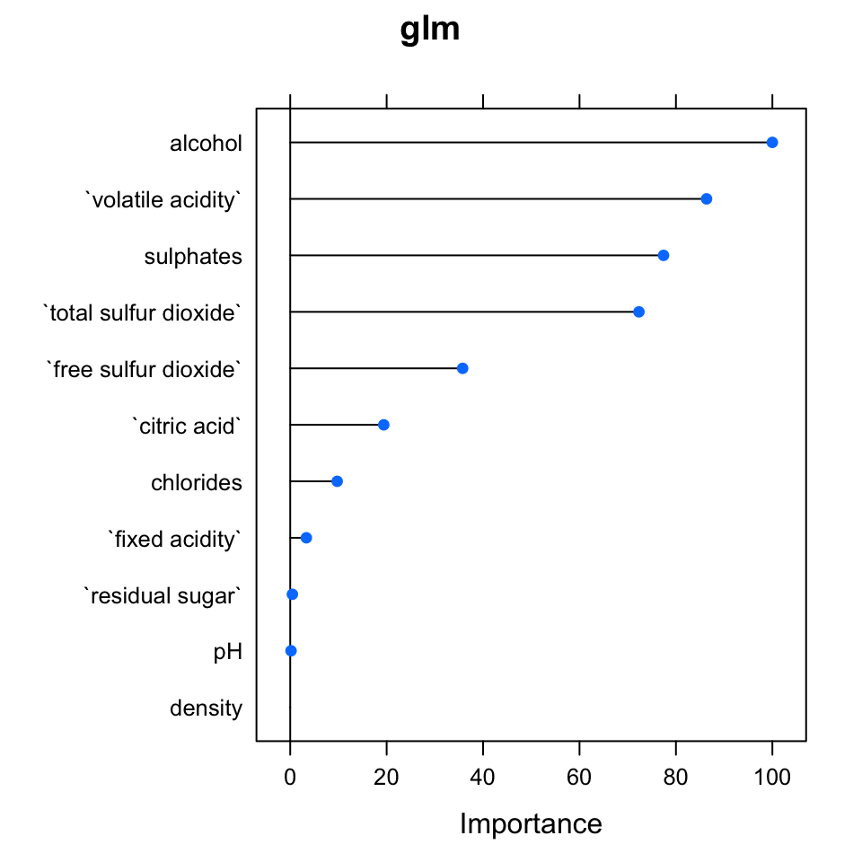

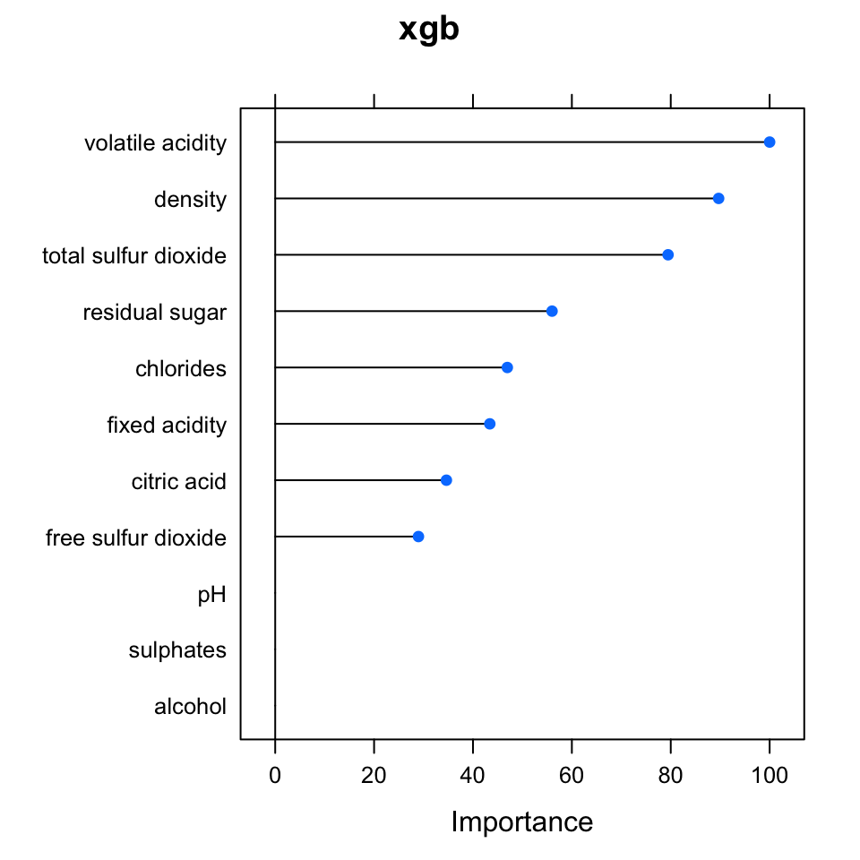

## Exercise: Assess model performance and variable importance

– Assess model performance

`xgb.pred = predict(xgb.fit, testScaled)`

`confusionMatrix(xgb.pred, testClass)`

– Assess variable importance

`plot(varImp(xgb.fit, scale = TRUE))`

## Addressing the Black Box Problem with Understandable Models

[figure not shown]

## An Understandable Model

### Fast and frugal decision trees

```r
library(FFTrees)
wine.df =  read_csv("winequality-red.csv")
wine.df = wine.df %>% mutate(goodwine = if_else(quality>5, TRUE, FALSE)) %>%
  select(-quality)

inTrain = createDataPartition(wine.df$goodwine, p = 3/4, list = FALSE)
train.wine.df = wine.df[inTrain, ]
test.wine.df = wine.df[-inTrain, ]

fft.fit = FFTrees(formula = goodwine~., data = train.wine.df, do.comp = FALSE)
```

## Fast and Frugal Decision Tree

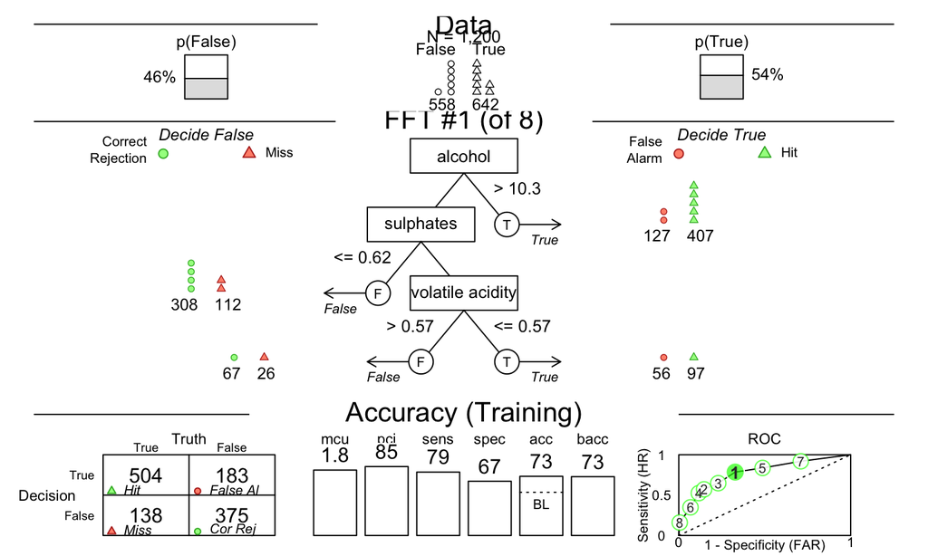

## Understandable (fft) and Sophisticated (xgb)

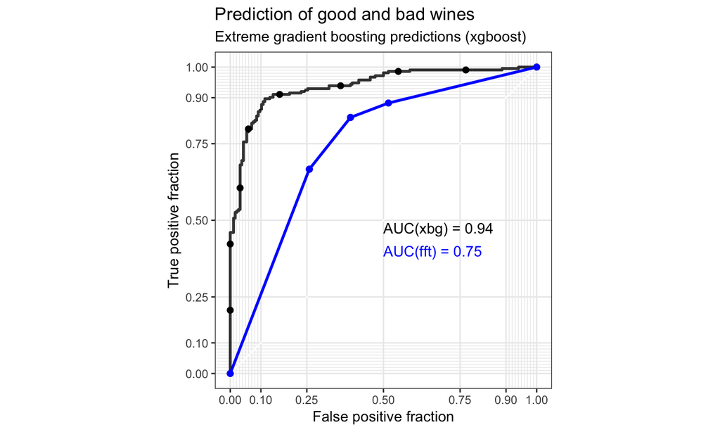

## Regression

### Prediction of continuous variables

– Similar process different performance metrics

```
- RMSE--Root mean square error

- MAE--Mean absolute error
```

– General issues with model metrics

```
- How to penalize the model for large deviations?

- Does the sign of the error matter?

- Similar to the issue with classificaiton: Are misses and false alarms equally problematic?
```

– Cost sensitive learning and optimal \(\beta\)

[figure not shown]

## Simplified Machine Learning Process

– Partition data into training and test sets

– Pre-process data and select features

– Tune model hyperparameters with cross validation

– Estimate variable importance

– Assess predictions and model performance with test data

– Compare model performance

**At each step be sure to model with people in mind**